# HW1

## Homework Assignment: Heart Failure Prediction Dataset Analysis and Exploratory Data Analysis (EDA)

Pandas is an important library in the Python for data analysis and manipulation. It provides ways to perform many tasks like: Reading and Writing Data, Data Cleaning, Data aggregation and grouping, Descriptive Statistics and more.

Instead of typing pandas every time you want to use a function or class from the pandas library, you can simply use **pd** as an alias to make your code shorter and more readable.

To learn more you can check this link [here](https://pandas.pydata.org/docs/user_guide/index.html#user-guide)

```python
import pandas as pd
```

**Matplotlib** is a widely used library in Python for creating static, animated, and interactive visualizations.

**The pyplot module** within Matplotlib, often imported as **plt**, provides an interface for creating plots and charts by calling simple functions.

To learn more you can check this link [here](https://matplotlib.org/stable/tutorials/index)

```python
import matplotlib.pyplot as plt
```

Import the mosaic function from the statsmodels library.

We are not importing the whole library here.

```python
from statsmodels.graphics.mosaicplot import mosaic
```

Read the CSV file (Comma Seperated Values) named heart.csv and store its contents in a DataFrame named df.

You need to upload the heart.csv file to the jupytarlab from the "Upload Files" option in the side section.

[Read_more](https://pandas.pydata.org/docs/reference/api/pandas.read_csv.html)

```python
#upload the dataset
heart_disdease_df = pd.read_csv('heart.csv')
```

```python
# Display the first few rows of the dataset
heart_disdease_df.head()
```

|  | Age | Sex | ChestPainType | RestingBP | Cholesterol | FastingBS | RestingECG | MaxHR | ExerciseAngina | Oldpeak | ST_Slope | HeartDisease |
| --- | --- | --- | --- | --- | --- | --- | --- | --- | --- | --- | --- | --- |
| 0 | 40 | M | ATA | 140 | 289 | 0 | Normal | 172 | N | 0.0 | Up | 0 |
| 1 | 49 | F | NAP | 160 | 180 | 0 | Normal | 156 | N | 1.0 | Flat | 1 |
| 2 | 37 | M | ATA | 130 | 283 | 0 | ST | 98 | N | 0.0 | Up | 0 |
| 3 | 48 | F | ASY | 138 | 214 | 0 | Normal | 108 | Y | 1.5 | Flat | 1 |
| 4 | 54 | M | NAP | 150 | 195 | 0 | Normal | 122 | N | 0.0 | Up | 0 |

```python
# Generate descriptive statistics for the dataset
heart_disdease_df.describe()
```

|  | Age | RestingBP | Cholesterol | FastingBS | MaxHR | Oldpeak | HeartDisease |
| --- | --- | --- | --- | --- | --- | --- | --- |
| count | 918.000000 | 918.000000 | 918.000000 | 918.000000 | 918.000000 | 918.000000 | 918.000000 |
| mean | 53.510893 | 132.396514 | 198.799564 | 0.233115 | 136.809368 | 0.887364 | 0.553377 |
| std | 9.432617 | 18.514154 | 109.384145 | 0.423046 | 25.460334 | 1.066570 | 0.497414 |
| min | 28.000000 | 0.000000 | 0.000000 | 0.000000 | 60.000000 | -2.600000 | 0.000000 |
| 25% | 47.000000 | 120.000000 | 173.250000 | 0.000000 | 120.000000 | 0.000000 | 0.000000 |
| 50% | 54.000000 | 130.000000 | 223.000000 | 0.000000 | 138.000000 | 0.600000 | 1.000000 |
| 75% | 60.000000 | 140.000000 | 267.000000 | 0.000000 | 156.000000 | 1.500000 | 1.000000 |
| max | 77.000000 | 200.000000 | 603.000000 | 1.000000 | 202.000000 | 6.200000 | 1.000000 |

```python
#display 'Age' column
heart_disdease_df['Age']
```

```
0      40
1      49
2      37
3      48
4      54
       ..
913    45
914    68
915    57
916    57
917    38
Name: Age, Length: 918, dtype: int64
```

```python
#Display the maximum value in 'Age' column
heart_disdease_df['Age'].max()
```

```
77
```

**Question:** find the minimum value for the Cholesterol column

```python
#write your code
heart_disdease_df['Cholesterol'].min()
```

```
0
```

### Value_counts

This function counts the number of times each unique value appears in the specified column. It is usually used with Categorial Data.

Read more about [value_counts](https://pandas.pydata.org/docs/reference/api/pandas.Series.value_counts.html)

Count the occurrences of each unique value in the 'ChestPainType' column of the DataFrame heart_disease_df

```python
# Get the count of unique values in the 'ChestPainType' column
heart_disdease_df['ChestPainType'].value_counts()
```

```
ChestPainType
ASY    496
NAP    203
ATA    173
TA      46
Name: count, dtype: int64
```

**Question:** Choose a categorial feature and get its value counts

```python
#write your code
heart_disdease_df['ST_Slope'].value_counts()
```

```
ST_Slope
Flat    460
Up      395
Down     63
Name: count, dtype: int64
```

**Question:** How many patients have heart disease (HeartDisease = 1) versus those who do not (HeartDisease = 0)? Hint: use value_counts

```python
#write your code
heart_disdease_df['HeartDisease'].value_counts()
```

```
HeartDisease
1    508
0    410
Name: count, dtype: int64
```

### Filtering

'HeartDisease' is the target column and it contain binar values(0, 1). HeartDisease = 1 means this patient has a heart disease. HeartDisease = 0 means this patient does not a heart disease.

heart_disease_df['HeartDisease'] == 1:

This condition checks each row in the HeartDisease column to see if the value is 1.

heart_disease_df[heart_disease_df['HeartDisease'] == 1] filters the heart_disease_df DataFrame by selecting only the rows where the HeartDisease column is equal to 1.

The filtered DataFrame is assigned to a new variable with_heart_disease_df.

[Read_more](https://pandas.pydata.org/docs/user_guide/indexing.html#boolean-indexing)

You can also check [this youtube video](https://www.youtube.com/watch?v=wtlRLl0DVho&list=PLuRv1IekA3YVwzaWa2Kp7bgIVcJsJ5XGW&index=4)

```python
# Filter the dataset to include only the rows where patients have heart disease (HeartDisease = 1)
with_heart_disdease_df = heart_disdease_df[heart_disdease_df['HeartDisease'] == 1]
# Display the filtered dataset containing only patients with heart disease
with_heart_disdease_df
```

|  | Age | Sex | ChestPainType | RestingBP | Cholesterol | FastingBS | RestingECG | MaxHR | ExerciseAngina | Oldpeak | ST_Slope | HeartDisease |
| --- | --- | --- | --- | --- | --- | --- | --- | --- | --- | --- | --- | --- |
| 1 | 49 | F | NAP | 160 | 180 | 0 | Normal | 156 | N | 1.0 | Flat | 1 |
| 3 | 48 | F | ASY | 138 | 214 | 0 | Normal | 108 | Y | 1.5 | Flat | 1 |
| 8 | 37 | M | ASY | 140 | 207 | 0 | Normal | 130 | Y | 1.5 | Flat | 1 |
| 11 | 58 | M | ATA | 136 | 164 | 0 | ST | 99 | Y | 2.0 | Flat | 1 |
| 13 | 49 | M | ASY | 140 | 234 | 0 | Normal | 140 | Y | 1.0 | Flat | 1 |
| ... | ... | ... | ... | ... | ... | ... | ... | ... | ... | ... | ... | ... |
| 912 | 57 | F | ASY | 140 | 241 | 0 | Normal | 123 | Y | 0.2 | Flat | 1 |
| 913 | 45 | M | TA | 110 | 264 | 0 | Normal | 132 | N | 1.2 | Flat | 1 |
| 914 | 68 | M | ASY | 144 | 193 | 1 | Normal | 141 | N | 3.4 | Flat | 1 |
| 915 | 57 | M | ASY | 130 | 131 | 0 | Normal | 115 | Y | 1.2 | Flat | 1 |
| 916 | 57 | F | ATA | 130 | 236 | 0 | LVH | 174 | N | 0.0 | Flat | 1 |

508 rows × 12 columns

**Question:** Filter the dataset to include only male patients:

```python
#continue the code

male_df= heart_disdease_df[heart_disdease_df['Sex'] == 'M']
male_df
```

|  | Age | Sex | ChestPainType | RestingBP | Cholesterol | FastingBS | RestingECG | MaxHR | ExerciseAngina | Oldpeak | ST_Slope | HeartDisease |
| --- | --- | --- | --- | --- | --- | --- | --- | --- | --- | --- | --- | --- |
| 0 | 40 | M | ATA | 140 | 289 | 0 | Normal | 172 | N | 0.0 | Up | 0 |
| 2 | 37 | M | ATA | 130 | 283 | 0 | ST | 98 | N | 0.0 | Up | 0 |
| 4 | 54 | M | NAP | 150 | 195 | 0 | Normal | 122 | N | 0.0 | Up | 0 |
| 5 | 39 | M | NAP | 120 | 339 | 0 | Normal | 170 | N | 0.0 | Up | 0 |
| 7 | 54 | M | ATA | 110 | 208 | 0 | Normal | 142 | N | 0.0 | Up | 0 |
| ... | ... | ... | ... | ... | ... | ... | ... | ... | ... | ... | ... | ... |
| 911 | 59 | M | ASY | 164 | 176 | 1 | LVH | 90 | N | 1.0 | Flat | 1 |
| 913 | 45 | M | TA | 110 | 264 | 0 | Normal | 132 | N | 1.2 | Flat | 1 |
| 914 | 68 | M | ASY | 144 | 193 | 1 | Normal | 141 | N | 3.4 | Flat | 1 |
| 915 | 57 | M | ASY | 130 | 131 | 0 | Normal | 115 | Y | 1.2 | Flat | 1 |
| 917 | 38 | M | NAP | 138 | 175 | 0 | Normal | 173 | N | 0.0 | Up | 0 |

725 rows × 12 columns

```python
# Filter the dataset to include only the rows where patients have heart disease (HeartDisease = 1)
has_heart_disease_df = heart_disdease_df[heart_disdease_df['HeartDisease'] == 1]


# Calculate the count of each unique value in the 'ChestPainType' column
# for the filtered dataset containing only patients with heart disease
has_heart_disease_df['ChestPainType'].value_counts()
```

```
ASY    392
NAP     72
ATA     24
TA      20
Name: ChestPainType, dtype: int64
```

### Aggregation

**Aggregation** in pandas means computing a summary statistic about a group of data. This is typically done after grouping data using the **groupby** function.

Aggregation produce a single result for each group, providing insights into the data.

[Read_more](https://pandas.pydata.org/docs/reference/api/pandas.DataFrame.groupby.html)

Group the data in the heart_disease_df DataFrame by the HeartDisease column and then calculate the mean age for each group.

HearDisease Column has 2 distinct values 0,1 => then there are two groups of data. Clculate the mean age for the group of data with HearDisease==1 then calculate it with the group with HearDisease==0

```python
#Calculate the average age of patients with heart disease and those without.

heart_disdease_df.groupby('HeartDisease')['Age'].mean()
```

```
HeartDisease
0    50.551220
1    55.899606
Name: Age, dtype: float64
```

**Insight** Mean age for people with heart disease > mean age for people with no heart disease

**Question:** Calculate the average resting blood pressure of male and female patients:

```python
#write your code
heart_disdease_df.groupby('Sex')['RestingBP'].mean()
```

```
Sex
F    132.212435
M    132.445517
Name: RestingBP, dtype: float64
```

## Correlation

**Note:**

**Positive Correlation:** Values closer to 1 indicate a strong positive linear relationship, meaning as one variable increases, the other also increases.

**Negative Correlation:** Values closer to -1 indicate a strong negative linear relationship, meaning as one variable increases, the other decreases.

**Zero Correlation:** A value close to 0 indicates no linear relationship between the variables.

What is the correlation between Age and MaxHR?

```python
heart_disdease_df['Age'].corr(heart_disdease_df['MaxHR'])
```

```
-0.38204467503197054
```

It is a Negative Correlation, let's visualize it:

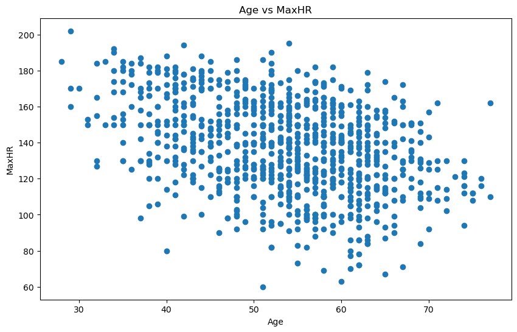

```python
# Create a scatter plot for Age vs MaxHR
plt.figure(figsize=(10, 6))
plt.scatter(heart_disdease_df['Age'], heart_disdease_df['MaxHR'])

# Add title and labels
plt.title('Age vs MaxHR')
plt.xlabel('Age')
plt.ylabel('MaxHR')

# Display the plot
plt.show()
```

**Insight**

As age increases, MaxHr dicreases

Notice that, MaxHR is the maximum heart rate achieved.

It makes sense!

**Question:** What is the correlation between Age and RestingBP?

**Side note:**

Resting Blood Pressure (RestingBP) is the blood pressure in an individual's arteries when they are at rest.

```python
#write your code
heart_disdease_df['Age'].corr(heart_disdease_df['RestingBP'])
```

```
0.2543993561515447
```

**Question:**

Create a scatter plot for Age vs RestingBP

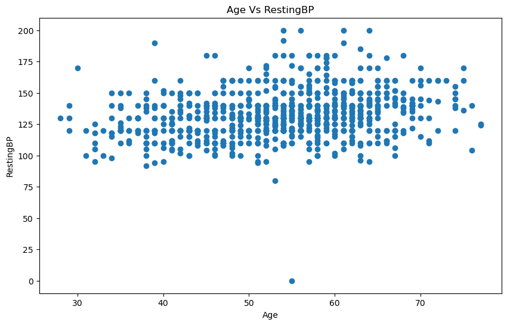

```python
#write your code
plt.figure(figsize=(10,6))
plt.scatter(heart_disdease_df['Age'],heart_disdease_df['RestingBP'])

plt.title("Age Vs RestingBP")
plt.xlabel("Age")
plt.ylabel("RestingBP")
plt.show()
```

## BoxPlot

#### comparing Ages for patients with and without heart disease

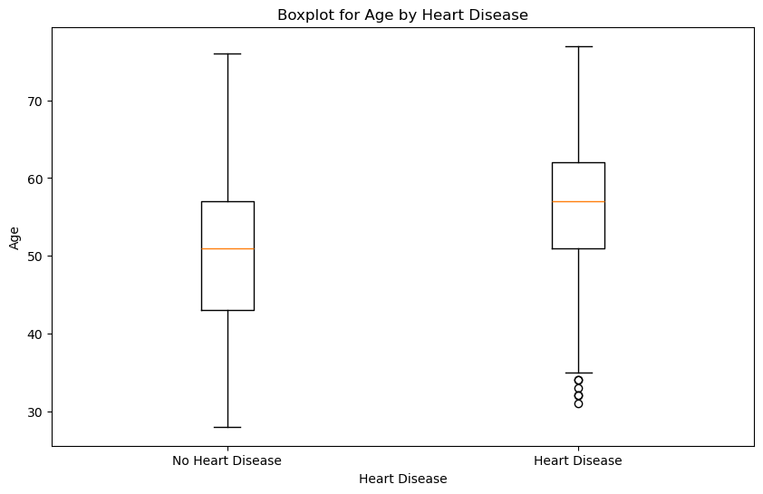

```python
# Create two dataframes: one for patients with heart disease and one for those without
with_heart_disease_df = heart_disdease_df[heart_disdease_df['HeartDisease'] == 1]
no_heart_disease_df = heart_disdease_df[heart_disdease_df['HeartDisease'] == 0]

# Create a figure with a specified size
plt.figure(figsize=(10, 6))

# Create a boxplot comparing the Ages for patients with and without heart disease
plt.boxplot([no_heart_disease_df['Age'], with_heart_disease_df['Age']],
            labels=['No Heart Disease', 'Heart Disease'])

# Add a title to the plot
plt.title('Boxplot for Age by Heart Disease')

# Add a label to the x-axis
plt.xlabel('Heart Disease')

# Add a label to the y-axis
plt.ylabel('Age')

# Display the plot
plt.show()
```

**Insight**

We can see that patients with heart disease tend to be older, on average, and that there are some younger outliers in the heart disease group.

**Question**

Compare MaxHR levels for patients with and without heart disease

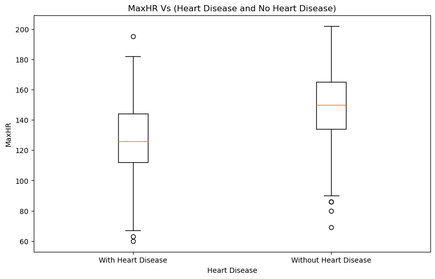

```python
#write your code
plt.figure(figsize=(10,6))
plt.boxplot([with_heart_disease_df['MaxHR'],no_heart_disease_df['MaxHR']],
            labels=['With Heart Disease','Without Heart Disease'])

plt.title("MaxHR Vs (Heart Disease and No Heart Disease)")
plt.xlabel("Heart Disease")
plt.ylabel("MaxHR")
plt.show()
```

**Question**

Create a boxplot comparing the age levels for male and female patients

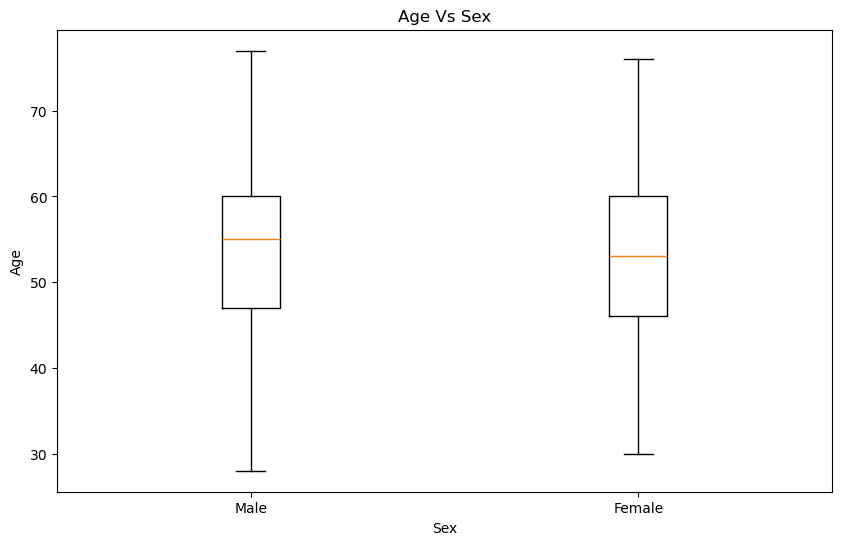

```python
#write your code
male_df= heart_disdease_df[heart_disdease_df['Sex'] == 'M']
female_df= heart_disdease_df[heart_disdease_df['Sex'] == 'F']

plt.figure(figsize=(10,6))
plt.boxplot([male_df['Age'],female_df['Age']],
            labels=['Male','Female'])

plt.title("Age Vs Sex")
plt.xlabel("Sex")
plt.ylabel("Age")
plt.show()
```

## Histogram

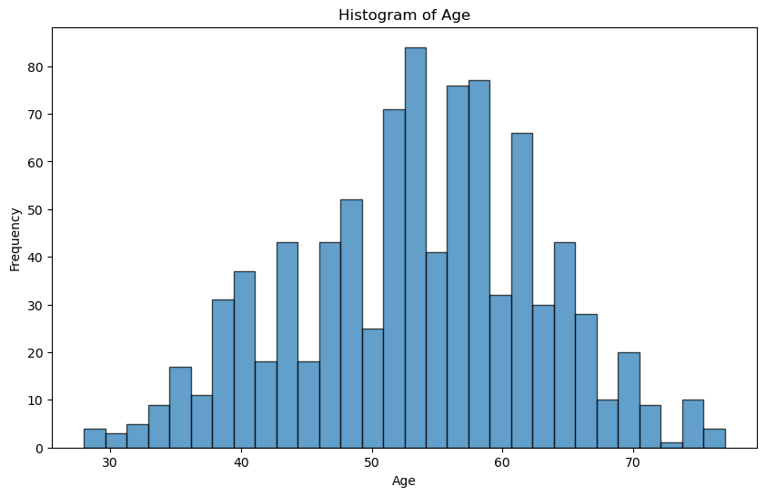

```python
# Create a histogram for the Age feature
# Set the size of the figure to be 10 inches wide and 6 inches tall
plt.figure(figsize=(10, 6))

# Plot the histogram for the 'Age' column with 30 bins, black edges, and 70% transparency
plt.hist(heart_disdease_df['Age'], bins=30, edgecolor='k', alpha=0.7)

# Add a title to the plot
plt.title('Histogram of Age')

# Label the x-axis as 'Age'
plt.xlabel('Age')

# Label the y-axis as 'Frequency'
plt.ylabel('Frequency')

# Display the plot
plt.show()
```

Let's try to change bins to 10

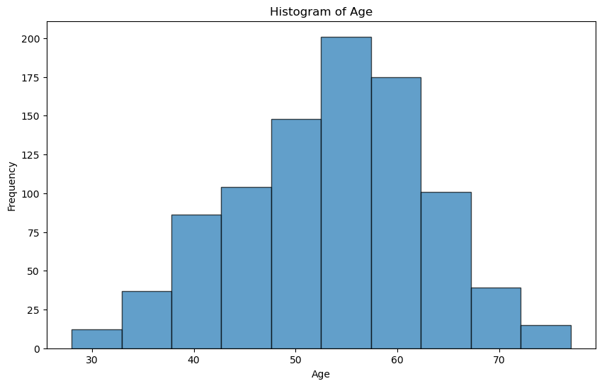

```python
# Create a histogram for the Age feature
# Set the size of the figure to be 10 inches wide and 6 inches tall
plt.figure(figsize=(10, 6))

# Plot the histogram for the 'Age' column with 30 bins, black edges, and 70% transparency
plt.hist(heart_disdease_df['Age'], bins=10, edgecolor='k', alpha=0.7)

# Add a title to the plot
plt.title('Histogram of Age')

# Label the x-axis as 'Age'
plt.xlabel('Age')

# Label the y-axis as 'Frequency'
plt.ylabel('Frequency')

# Display the plot
plt.show()
```

**Insight**

The peak frequencies occur around the ages of 50 to 60, indicating that these age groups are the most common in the dataset.

The ages in the dataset range from about 30 to around 75 years.

The histogram shows a roughly normal (bell-shaped) distribution of ages with a slight skew towards older ages.

**Question**

Create a histogram for the Cholesterol feature

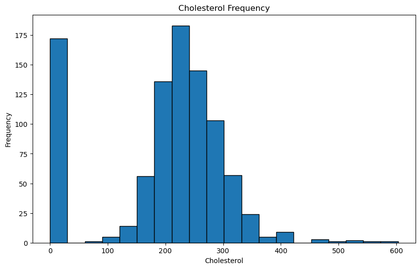

```python
#write your code
plt.figure(figsize=(10,6))
plt.hist(x=heart_disdease_df['Cholesterol'],bins=20,edgecolor='k')

plt.title("Cholesterol Frequency")
plt.xlabel('Cholesterol')
plt.ylabel('Frequency')

plt.show()
```

## Density Plot

```python
#Step By Step

# List of unique ST_Slope types
st_slope_types = heart_disdease_df['ST_Slope'].unique()

#Display unique ST_Slope types

st_slope_types
```

```
array(['Up', 'Flat', 'Down'], dtype=object)
```

```python
#display the dataset that includes only the rows where the ST_Slope is 'Up'
heart_disdease_df[heart_disdease_df['ST_Slope'] == 'Up']
```

|  | Age | Sex | ChestPainType | RestingBP | Cholesterol | FastingBS | RestingECG | MaxHR | ExerciseAngina | Oldpeak | ST_Slope | HeartDisease |
| --- | --- | --- | --- | --- | --- | --- | --- | --- | --- | --- | --- | --- |
| 0 | 40 | M | ATA | 140 | 289 | 0 | Normal | 172 | N | 0.0 | Up | 0 |
| 2 | 37 | M | ATA | 130 | 283 | 0 | ST | 98 | N | 0.0 | Up | 0 |
| 4 | 54 | M | NAP | 150 | 195 | 0 | Normal | 122 | N | 0.0 | Up | 0 |
| 5 | 39 | M | NAP | 120 | 339 | 0 | Normal | 170 | N | 0.0 | Up | 0 |
| 6 | 45 | F | ATA | 130 | 237 | 0 | Normal | 170 | N | 0.0 | Up | 0 |
| ... | ... | ... | ... | ... | ... | ... | ... | ... | ... | ... | ... | ... |
| 903 | 56 | M | ATA | 130 | 221 | 0 | LVH | 163 | N | 0.0 | Up | 0 |
| 906 | 55 | F | ATA | 132 | 342 | 0 | Normal | 166 | N | 1.2 | Up | 0 |
| 908 | 63 | M | ASY | 140 | 187 | 0 | LVH | 144 | Y | 4.0 | Up | 1 |
| 910 | 41 | M | ATA | 120 | 157 | 0 | Normal | 182 | N | 0.0 | Up | 0 |
| 917 | 38 | M | NAP | 138 | 175 | 0 | Normal | 173 | N | 0.0 | Up | 0 |

395 rows × 12 columns

```python
#display age column from the dataset that includes only the rows where the ST_Slope is 'Up'
heart_disdease_df[heart_disdease_df['ST_Slope'] == 'Up']['Age']
```

```
0      40
2      37
4      54
5      39
6      45
       ..
903    56
906    55
908    63
910    41
917    38
Name: Age, Length: 395, dtype: int64
```

#### density for Age by ST_Slope type 'Up'

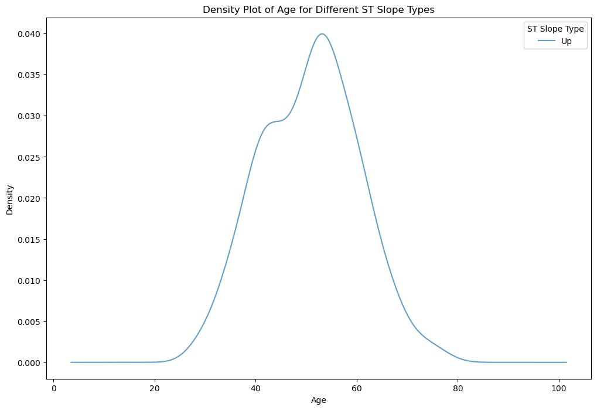

```python
# Create a figure for density plots
plt.figure(figsize=(12, 8))

# Plot the density for Age by ST_Slope type 'Up'
heart_disdease_df[heart_disdease_df['ST_Slope'] == 'Up']['Age'].plot(kind='density', alpha=0.7, label='Up')

# Add title and labels
plt.title('Density Plot of Age for Different ST Slope Types')
plt.xlabel('Age')
plt.ylabel('Density')

# Add a legend
plt.legend(title='ST Slope Type')

# Display the plot
plt.show()
```

#### density for Age by the three types of ST_Slope

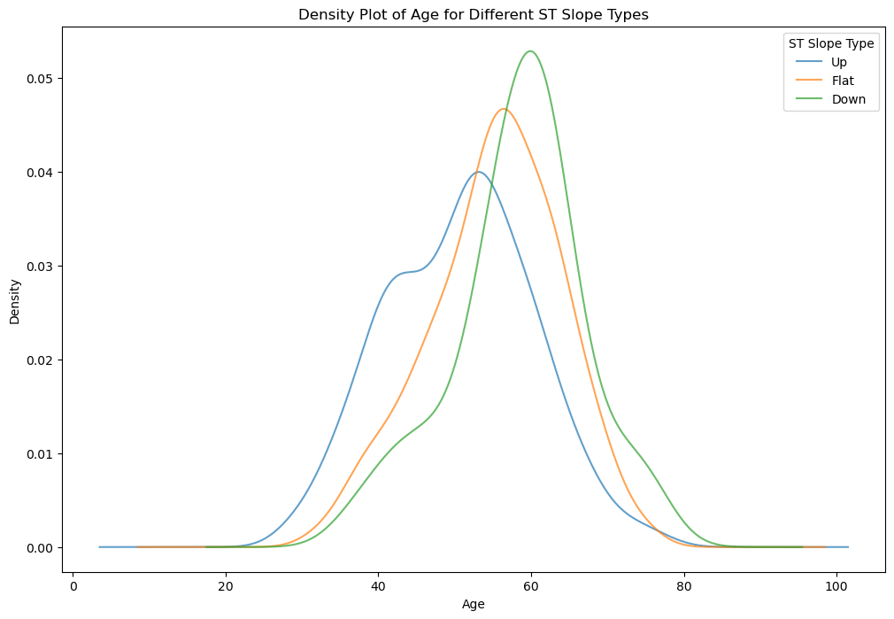

```python
# Create a figure for density plots
plt.figure(figsize=(12, 8))

# Plot the density for Age by ST_Slope type 'Up'
heart_disdease_df[heart_disdease_df['ST_Slope'] == 'Up']['Age'].plot(kind='density', alpha=0.7, label='Up')

# Plot the density for Age by ST_Slope type 'Flat'
heart_disdease_df[heart_disdease_df['ST_Slope'] == 'Flat']['Age'].plot(kind='density', alpha=0.7, label='Flat')

# Plot the density for Age by ST_Slope type 'Down'
heart_disdease_df[heart_disdease_df['ST_Slope'] == 'Down']['Age'].plot(kind='density', alpha=0.7, label='Down')

# Add title and labels
plt.title('Density Plot of Age for Different ST Slope Types')
plt.xlabel('Age')
plt.ylabel('Density')

# Add a legend
plt.legend(title='ST Slope Type')

# Display the plot
plt.show()
```

**Insight**

ST_Slope type correlates with age. Younger patients are more likely to have an ST_Slope of "Up", while older patients tend to have an ST_Slope of "Down".

### Now it is your turn!

**Question**

List the unique types of ChestPainType

```python
#write your code
heart_disdease_df['ChestPainType'].unique()
```

```
array(['ATA', 'NAP', 'ASY', 'TA'], dtype=object)
```

**Question**

Display the dataset that includes only the rows where the ChestPainType is 'ATA'

```python
#Write your code

ata_chest_pain = heart_disdease_df[heart_disdease_df['ChestPainType'] == 'ATA']
ata_chest_pain
```

|  | Age | Sex | ChestPainType | RestingBP | Cholesterol | FastingBS | RestingECG | MaxHR | ExerciseAngina | Oldpeak | ST_Slope | HeartDisease |
| --- | --- | --- | --- | --- | --- | --- | --- | --- | --- | --- | --- | --- |
| 0 | 40 | M | ATA | 140 | 289 | 0 | Normal | 172 | N | 0.0 | Up | 0 |
| 2 | 37 | M | ATA | 130 | 283 | 0 | ST | 98 | N | 0.0 | Up | 0 |
| 6 | 45 | F | ATA | 130 | 237 | 0 | Normal | 170 | N | 0.0 | Up | 0 |
| 7 | 54 | M | ATA | 110 | 208 | 0 | Normal | 142 | N | 0.0 | Up | 0 |
| 9 | 48 | F | ATA | 120 | 284 | 0 | Normal | 120 | N | 0.0 | Up | 0 |
| ... | ... | ... | ... | ... | ... | ... | ... | ... | ... | ... | ... | ... |
| 903 | 56 | M | ATA | 130 | 221 | 0 | LVH | 163 | N | 0.0 | Up | 0 |
| 904 | 56 | M | ATA | 120 | 240 | 0 | Normal | 169 | N | 0.0 | Down | 0 |
| 906 | 55 | F | ATA | 132 | 342 | 0 | Normal | 166 | N | 1.2 | Up | 0 |
| 910 | 41 | M | ATA | 120 | 157 | 0 | Normal | 182 | N | 0.0 | Up | 0 |
| 916 | 57 | F | ATA | 130 | 236 | 0 | LVH | 174 | N | 0.0 | Flat | 1 |

173 rows × 12 columns

**Question**

Display the age column of the dataset that includes only the rows where the ChestPainType is 'ATA'

```python
#Write your code
ata_chest_pain['Age']
```

```
0      40
2      37
6      45
7      54
9      48
       ..
903    56
904    56
906    55
910    41
916    57
Name: Age, Length: 173, dtype: int64
```

**Question**

Plot the density for Age by ChestPainType

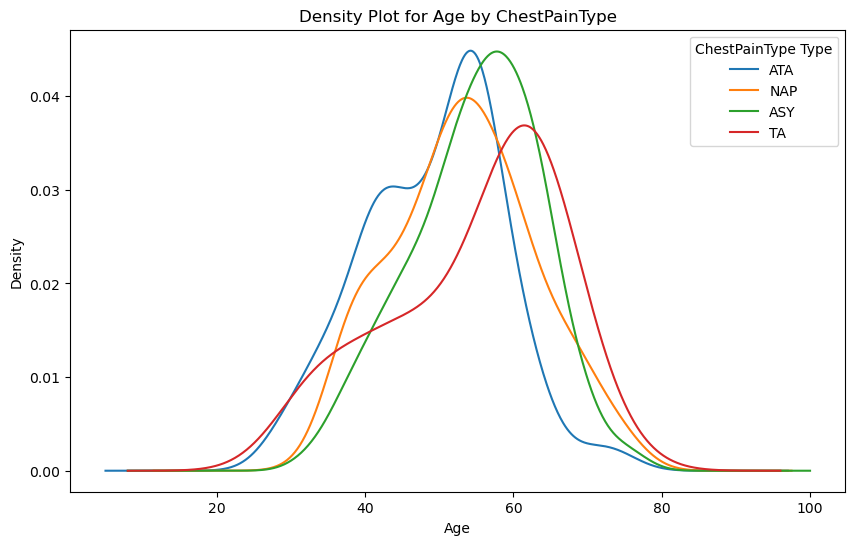

```python
#Write your code
ata_chest_pain_ages = heart_disdease_df[heart_disdease_df['ChestPainType'] == 'ATA']['Age']
nap_chest_pain_ages = heart_disdease_df[heart_disdease_df['ChestPainType'] == 'NAP']['Age']
asy_chest_pain_ages = heart_disdease_df[heart_disdease_df['ChestPainType'] == 'ASY']['Age']
ta_chest_pain_ages = heart_disdease_df[heart_disdease_df['ChestPainType'] == 'TA']['Age']

plt.figure(figsize=(10, 6))

ata_chest_pain_ages.plot(kind='density', label='ATA')
nap_chest_pain_ages.plot(kind='density', label='NAP')
asy_chest_pain_ages.plot(kind='density', label='ASY')
ta_chest_pain_ages.plot(kind='density', label='TA')

plt.title('Density Plot for Age by ChestPainType')
plt.xlabel('Age')
plt.ylabel('Density')

plt.legend(title='ChestPainType Type')
plt.show()
```

## Mosaic Plot

#### The mosaic plot between HeartDisease and ST_Slope

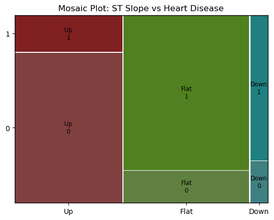

```python
# Prepare data for the mosaic plot
data = heart_disdease_df[['ST_Slope', 'HeartDisease']]

# Create the mosaic plot
plt.figure(figsize=(12, 8))
mosaic(data, ['ST_Slope', 'HeartDisease'], title='Mosaic Plot: ST Slope vs Heart Disease')

# Display the plot
plt.show()
```

**Insight**

In our dataset, the majority of Patients with a "Flat" and "Down" ST slope have heart disease. The majority of patients with an "Up" ST slope do not have heart disease.

**Question** create mosaic plot between HeartDisease and ExerciseAngina

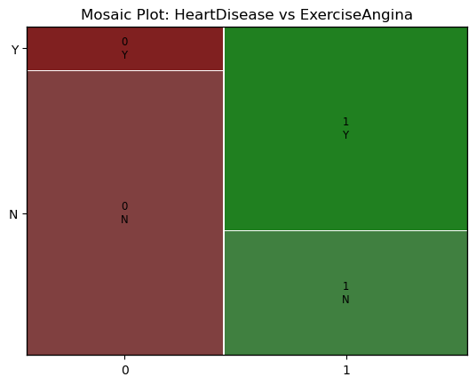

```python
#write your code
data = heart_disdease_df[['HeartDisease', 'ExerciseAngina']]

plt.figure(figsize=(10, 6))
mosaic(data, ['HeartDisease', 'ExerciseAngina'], title='Mosaic Plot: HeartDisease vs ExerciseAngina')

plt.show()
```